# lab1

```r
coef(mod1)
```

```
## (Intercept)       speed
##  -17.579095    3.932409
```

```r
summary(mod1)
```

```
##
## Call:
## lm(formula = dist ~ speed, data = cars)
##
## Residuals:
##     Min      1Q  Median      3Q     Max
## -29.069  -9.525  -2.272   9.215  43.201
##
## Coefficients:
##             Estimate Std. Error t value Pr(>|t|)
## (Intercept) -17.5791     6.7584  -2.601   0.0123 *
## speed         3.9324     0.4155   9.464 1.49e-12 ***
## ---
## Signif. codes:  0 '***' 0.001 '**' 0.01 '*' 0.05 '.' 0.1 ' ' 1
##
## Residual standard error: 15.38 on 48 degrees of freedom
## Multiple R-squared:  0.6511, Adjusted R-squared:  0.6438
## F-statistic: 89.57 on 1 and 48 DF,  p-value: 1.49e-12
```

Valori stimati dal modello:

```r
fitted(mod1)
```

```
##         1         2         3         4         5         6         7
## -1.849460 -1.849460  9.947766  9.947766 13.880175 17.812584 21.744993
##         8         9        10        11        12        13        14
## 21.744993 21.744993 25.677401 25.677401 29.609810 29.609810 29.609810
##        15        16        17        18        19        20        21
## 29.609810 33.542219 33.542219 33.542219 33.542219 37.474628 37.474628
##        22        23        24        25        26        27        28
## 37.474628 37.474628 41.407036 41.407036 41.407036 45.339445 45.339445
##        29        30        31        32        33        34        35
## 49.271854 49.271854 49.271854 53.204263 53.204263 53.204263 53.204263
##        36        37        38        39        40        41        42
## 57.136672 57.136672 57.136672 61.069080 61.069080 61.069080 61.069080
##        43        44        45        46        47        48        49
## 61.069080 68.933898 72.866307 76.798715 76.798715 76.798715 76.798715
##        50
## 80.731124
```

```r
summary(fitted(mod1))
```

```
##    Min. 1st Qu.  Median    Mean 3rd Qu.    Max.
##  -1.849  29.610  41.407  42.980  57.137  80.731
```

Analizziamo ora i residui: I residui, detti anche scarti, rappresentano infatti le differenze tra i valori osservati nel dataset e i valori stimati calcolati con l’equazione di regressione “fitted(mod1)”. In altre parole, i residui indicano la variabilità dei dati attorno alla retta di regressione.

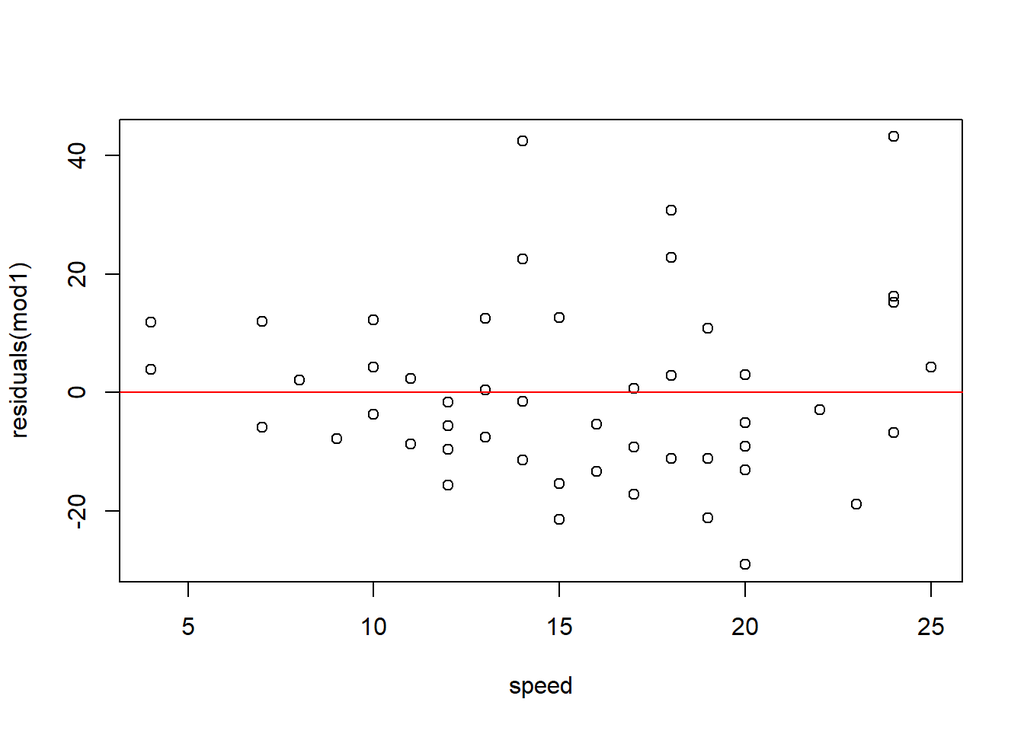

```r
plot(residuals(mod1) ~ speed, data = cars)
abline(h = 0, col = "red")
```

Dobbiamo verificare che i residui abbiano: 1)media 0 2)varianza costante 3)distribuzione normale 4)incorrelati tra loro

**1.**

```r
mean(residuals(mod1)) #la media è 0
```

```
## [1] 8.65974e-17
```

**2.** verifichiamo che la varianza sia omogenea

```r
var(residuals(mod1))
```

```
## [1] 231.7045
```

```r
cor(residuals(mod1),cars$speed) #non c'è correlazione
```

```
## [1] 8.058406e-17
```

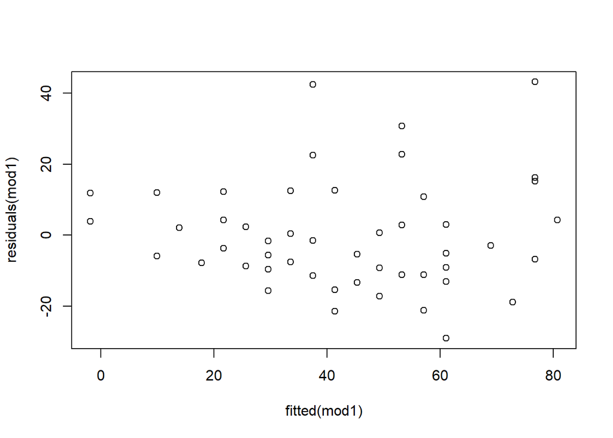

```r
plot(residuals(mod1)~fitted(mod1))
```

i punti tendono a disperdersi piu verso la parte destra del grafico ma sembra ok

**3.** verificabile attraverso il grafico dei quantili qqPlot

```r
par(mfrow=c(1,2))
qqPlot(residuals(mod1))
```

```
## [1] 49 23
```

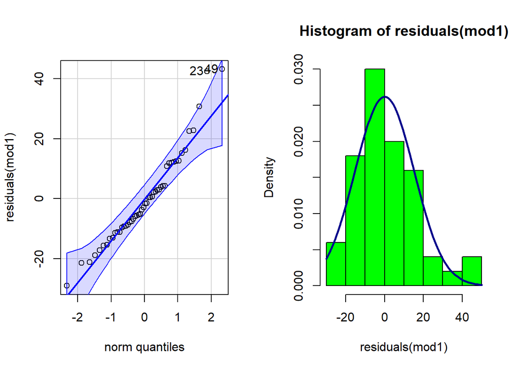

```r
hist(residuals(mod1), prob=TRUE, col="green")
curve(dnorm(x,mean=0, sd=sd(residuals(mod1))), add=TRUE, lwd=2.5, col="darkBlue")
```

```r
summary(mod1)
```

```
##
## Call:
## lm(formula = dist ~ speed, data = cars)
##
## Residuals:
##     Min      1Q  Median      3Q     Max
## -29.069  -9.525  -2.272   9.215  43.201
##
## Coefficients:
##             Estimate Std. Error t value Pr(>|t|)
## (Intercept) -17.5791     6.7584  -2.601   0.0123 *
## speed         3.9324     0.4155   9.464 1.49e-12 ***
## ---
## Signif. codes:  0 '***' 0.001 '**' 0.01 '*' 0.05 '.' 0.1 ' ' 1
##
## Residual standard error: 15.38 on 48 degrees of freedom
## Multiple R-squared:  0.6511, Adjusted R-squared:  0.6438
## F-statistic: 89.57 on 1 and 48 DF,  p-value: 1.49e-12
```

```r
sd(residuals(mod1))
```

```
## [1] 15.22184
```

Tuttavia, l’ipotesi di normalità dei residui non è così importante come le altre ipotesi. Si dimostra infatti che, soprattutto per campioni numerosi, la regressione lineare è abbastanza robusta alla non Normalità distributiva degli errori.

**4.** Le variabili indipendenti sono incorrelate con l’errore? Se una variabile esplicativa è correlata con il termine d’errore, puoi utilizzare questa variabile esplicativa per predire quale sarà l’errore del modello di regressione. E questo non va bene, perché la componente di errore di un modello di previsione deve essere imprevedibile.

Per verificare se questo è il caso del tuo modello, devi costruire tanti grafici di dispersione quante solo le x del tuo modello di regressione. Sull’asse orizzontale devi mettere i valori della x, mentre sull’asse verticale i valori dei residui.

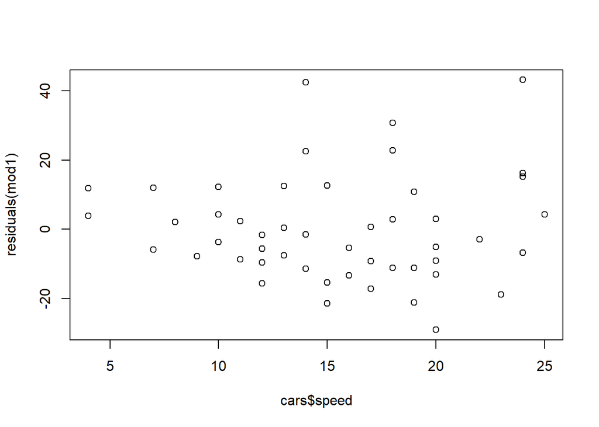

```r
plot(residuals(mod1)~cars$speed)
```

Osservando il grafico, l’ipotesi è confermata se non è individuabile nessuna relazione tra le due variabili.

# 2 Previsione e incertezza

Una volta che abbiamo un modello adattato, possiamo usarlo per fare previsioni sui valori di Y per diversi valori della covariata X. In R possiamo usare la funzione fitted per derivare il valore previsto per il campione usato per adattare il modello, mentre predict può essere utilizzato per derivare il valore stimato di Y per un valore diverso di X (sebbene per impostazione predefinita emetta i valori previsti alle x osservate).

```r
pr<-predict(mod1, newdata = data.frame(speed = 17), se.fit = TRUE)
pr
```

```
## $fit
##        1
## 49.27185
##
## $se.fit
## [1] 2.274339
##
## $df
## [1] 48
##
## $residual.scale
## [1] 15.37959
```

# 3 Verifica delle ipotesi del modello

Per ottenere le stime dei minimi quadrati dei coefficienti di regressione lineare non vengono fatte ipotesi forti: assumiamo solo che la relazione tra X e Y possa essere approssimata abbastanza bene da una funzione lineare. Per fare inferenza anche sui parametri del modello lineare e sulla funzione di regressione stimata vengono fatte alcune ipotesi aggiuntive, vale a dire

Linearità (di nuovo): $y_i = \beta_0 + \beta_1 x_i + \epsilon_i$ Indipendenza e varianze uguali: ciascuna $\epsilon_i$ è indipendente dall’altro $\epsilon_j$ e Var($\epsilon_i$)=$\sigma^2$ per ogni $i$ Non osserviamo gli errori di regressione ma osserviamo i residui del modello , ovvero la differenza tra i valori osservati e le stime (sotto il modello): $r_i = (y_i-\hat{y}_i)$. In R $r_i$ valori possono essere ottenuti usando la funzione residuals:

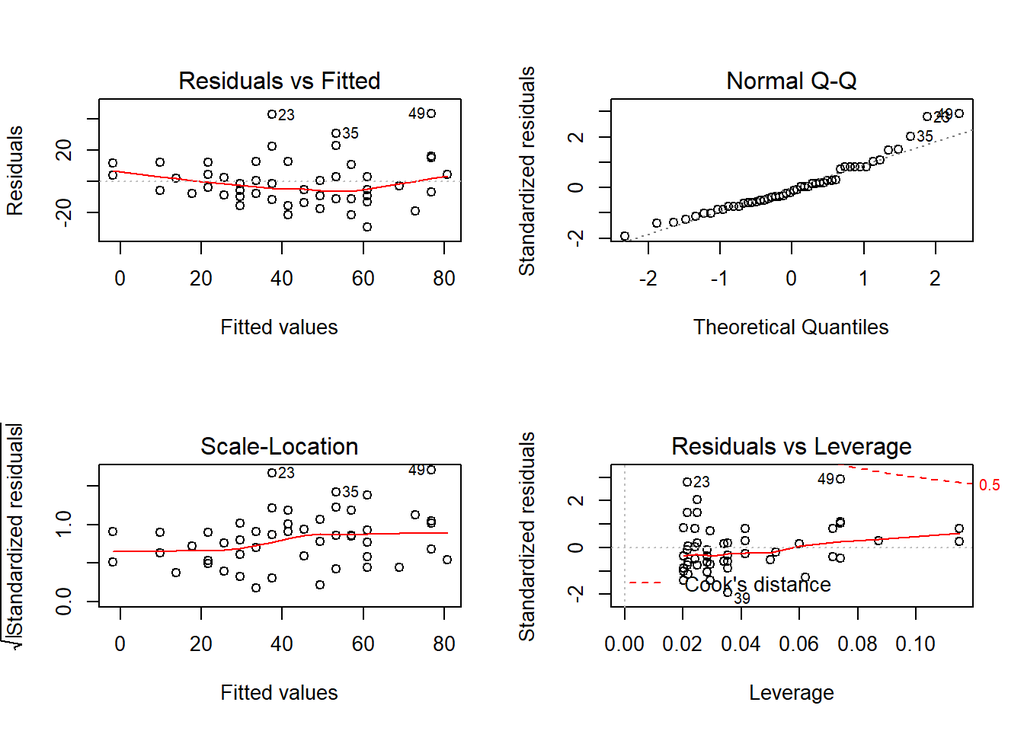

```r
par(mfrow=c(2,2))
plot(mod1)
```

# 4 Inferenza per il modello lineare nell’ipotesi di errori normali

Se si è pronti a fare l’ipotesi aggiuntiva che gli errori del modello lineare siano distribuiti secondo una distribuzione gaussiana, si può ricavare la distribuzione campionaria degli stimatori per i parametri del modello e per la previsione del modello. Questi possono quindi essere utilizzati per derivare intervalli di confidenza e test.

Esiste una relazione tra intervalli di confidenza e test a due code, possiamo quindi studiare la verifica di ipotesi con gli intervalli di confidenza in particolare

$$H_0: \beta_0 = 0 \quad VS \quad H_1:
\beta_0 \neq 0$$
e

$$H_0: \beta_1 = 0 \quad VS \quad H_1:
\beta_1 \neq 0$$

```r
tab<-summary(mod1)$coefficient
Beta0<-tab[1,1]
Beta1<-tab[2,1]
SEBeta0<-tab[1,2]
SEBeta1<-tab[2,2]
```

La statistica T sarà quindi calcolata:

$$T = \frac{\hat{\beta}_0 - 0}{\mbox{SE}[\hat{\beta}_0]}$$

```r
TB0<- (Beta0 - 0) / SEBeta0
TB0
```

```
## [1] -2.601058
```

$$T = \frac{\hat{\beta}_1 - 0}{\mbox{SE}[\hat{\beta}_1]}$$

```r
TB1<- (Beta1 - 0) / SEBeta1
TB1
```

```
## [1] 9.46399
```

ricaviamoci il livello di significatività p-value nel caso di ipotesi bi-laterale, quindi:

$$pvalue_{\beta0}=2*[1-Pr(T_{n-2} <
|T|)]$$

```r
pvalue<-2*(1-pt(abs(TB0), df=48))
pvalue
```

```
## [1] 0.01231882
```

$$pvalue_{\beta1}=2*[1-Pr(T_{n-2} <
|T|)]$$

```r
pvalue<-2*(1-pt(abs(TB1), df=48))
pvalue
```

```
## [1] 1.489919e-12
```

Rifiuteremo l’ipotesi dello scafo quando il valore p è “piccolo”. I valori limite tipici per identificare un piccolo valore p possono essere 0,05 o 0,01.

Se il test porta al rifiuto dell’ipotesi nulla allora il predittore è significativo

Un altro modo (più informativo) per eseguire l’inferenza sui valori dei **parametri** consiste nell’utilizzare intervalli di confidenza (a livelli pre-specificati1 - a):

```r
alpha<-0.05
confint(mod1, level = 1-alpha)
```

```
##                  2.5 %    97.5 %
## (Intercept) -31.167850 -3.990340
## speed         3.096964  4.767853
```

Sappiamo cosi’ che non è possibile rifiutare tutti i valori di un’ipotesi alternativa che rientrino nell’intervallo dell’intercetta(B0) e di speed(B1) a un livello di significatività alpha

La predict funzione consente di ottenere una previsione puntuale della funzione stimata per qualsiasi valore del predittore. È anche possibile ottenere intervalli di confidenza e di previsione: questi intervalli si basano su $T_{n-2}$ distribuzione e la loro costruzione dipendono anche dall’assunzione di errori gaussiani.

Dobbiamo anche distinguere tra previsioni della risposta media futura e previsioni di osservazioni future. Pensando al fitmodello, ci sono due tipi di previsioni che possono essere fatte per un dato $speed_0$:

```r
#intervalli di confidenza e predizione per valori di velocità singoli
confInterval<-predict(mod1, newdata=data.frame(speed=c(4,15,22)),interval = "confidence")

predInterval<-predict(mod1, newdata=data.frame(speed=c(4,15,22)),interval = "prediction")

confInterval
```

```
##        fit       lwr       upr
## 1 -1.84946 -12.32954  8.630624
## 2 41.40704  37.02115 45.792921
## 3 68.93390  61.89630 75.971494
```

```r
predInterval
```

```
##        fit       lwr       upr
## 1 -1.84946 -34.49984  30.80092
## 2 41.40704  10.17482  72.63925
## 3 68.93390  37.22044 100.64735
```

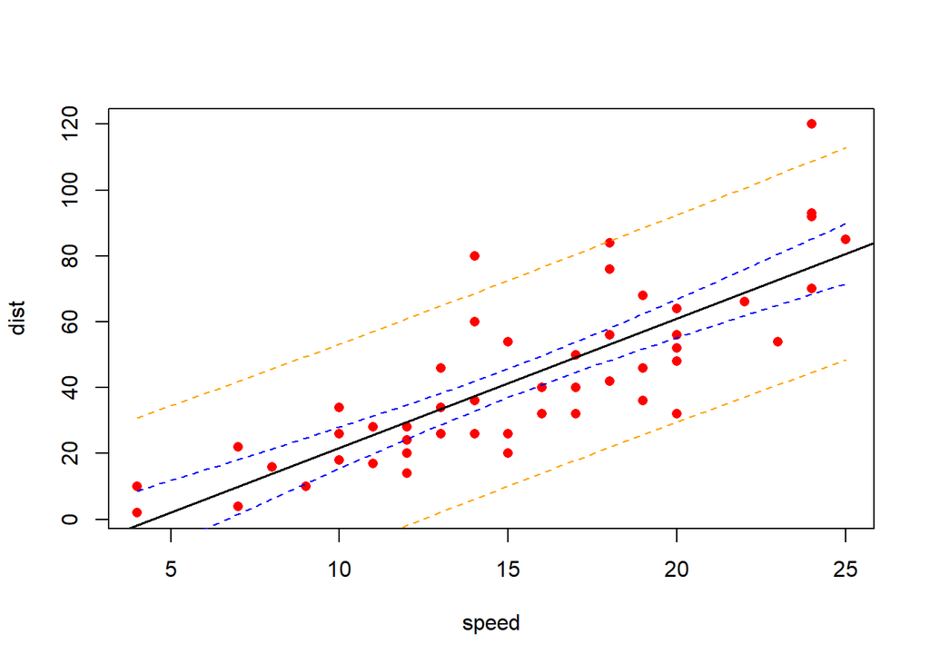

```r
#intervalli di confidenza e predizione per velocità del dataset
new_x<-seq(4.0,25.0, by=0.5)
confInterval_x<-predict(mod1, newdata=data.frame("speed"=new_x),interval = "confidence")
predInterval_x<-predict(mod1, newdata=data.frame("speed"=new_x),interval = "prediction")

plot(dist~speed, data=cars, col="red", pch=16)
abline(mod1, col="black", lwd=1.5)
#lower Line, colonna dei lower
lines(new_x,confInterval_x[,2], col="blue", lty=2)
#upper Line, colonna degli upper
lines(new_x,confInterval_x[,3], col="blue", lty=2)

#lower Line, colonna dei lower
lines(new_x,predInterval_x[,2], col="orange", lty=2)
#upper Line, colonna degli upper
lines(new_x,predInterval_x[,3], col="orange", lty=2)
```